# Practical Machine Learning - Course Project

Dan Johnson

August 7, 2017

## Background

Using devices such as Jawbone Up, Nike FuelBand, and Fitbit it is now possible to collect a large amount of data about personal activity relatively inexpensively. These type of devices are part of the quantified self movement - a group of enthusiasts who take measurements about themselves regularly to improve their health, to find patterns in their behavior, or because they are tech geeks. One thing that people regularly do is quantify how much of a particular activity they do, but they rarely quantify how well they do it. In this project, your goal will be to use data from accelerometers on the belt, forearm, arm, and dumbell of 6 participants. They were asked to perform barbell lifts correctly and incorrectly in 5 different ways. More information is available from the website here: http://groupware.les.inf.puc-rio.br/har (see the section on the Weight Lifting Exercise Dataset).

## Data

The training data for this project are available here: https://d396qusza40orc.cloudfront.net/predmachlearn/pml-training.csv

The test data are available here: https://d396qusza40orc.cloudfront.net/predmachlearn/pml-testing.csv

The data for this project come from this source: http://groupware.les.inf.puc-rio.br/har.

Note - much of the data has blanks, NULLs or ‘NA’ in the field. These items were changed to NA upon loading of the data.

```r
trainData <- read.csv("https://d396qusza40orc.cloudfront.net/predmachlearn/pml-training.csv", na.strings = c("", "NA", "#DIV/0!"))
dim(trainData)
```

```
## [1] 19622   160
```

```r
testData <- read.csv("https://d396qusza40orc.cloudfront.net/predmachlearn/pml-testing.csv", na.strings = c("", "NA", "#DIV/0!"))
dim(testData)
```

```
## [1]  20 160
```

There are also some columns that we simply don’t need for this analysis. We’ll remove those first.

Columns manually removed (1-7 in original data.frame):

1. X
2. user_name
3. raw_timestamp_1
4. raw_timestamp_2
5. cvtd_timestamp
6. new_window
7. num_window

At the same time, let’s get rid of those pesky NA valued columns.

```r
trainData <- trainData[,colSums(is.na(trainData))==0]
trainData <- trainData[,-c(1:7)]
dim(trainData)
```

```
## [1] 19622    53
```

```r
testData <- testData[,colSums(is.na(testData))==0]
testData <- testData[,-c(1:7)]
dim(testData)
```

```
## [1] 20 53
```

That kocked things down a bit; from 160 columns to 53. Let’s start getting our data setup for training, cross validation (test data from train data) and final test data (20 items).

## PreProcessing

Appears that the test data item is the final 20 row item that we will use to test once we have trained and tested, using cross-validation, in our model. Let’s go through and divide the original train data into a 60/40 split.

```r
library(caret, quietly = TRUE)
set.seed(777)
subSamples <- createDataPartition(y=trainData$classe, p=0.6, list = FALSE)
subTrainData <- trainData[subSamples,]
subTestData <- trainData[-subSamples,]

dim(subTrainData)
```

```
## [1] 11776    53
```

```r
dim(subTestData)
```

```
## [1] 7846   53
```

## Check Predicted Values

Let’s make sure that we have good representation of the predicted value in our subTrainData and subTestData an that we aren’t overweighted or imbalanced in the predictor value, classe.

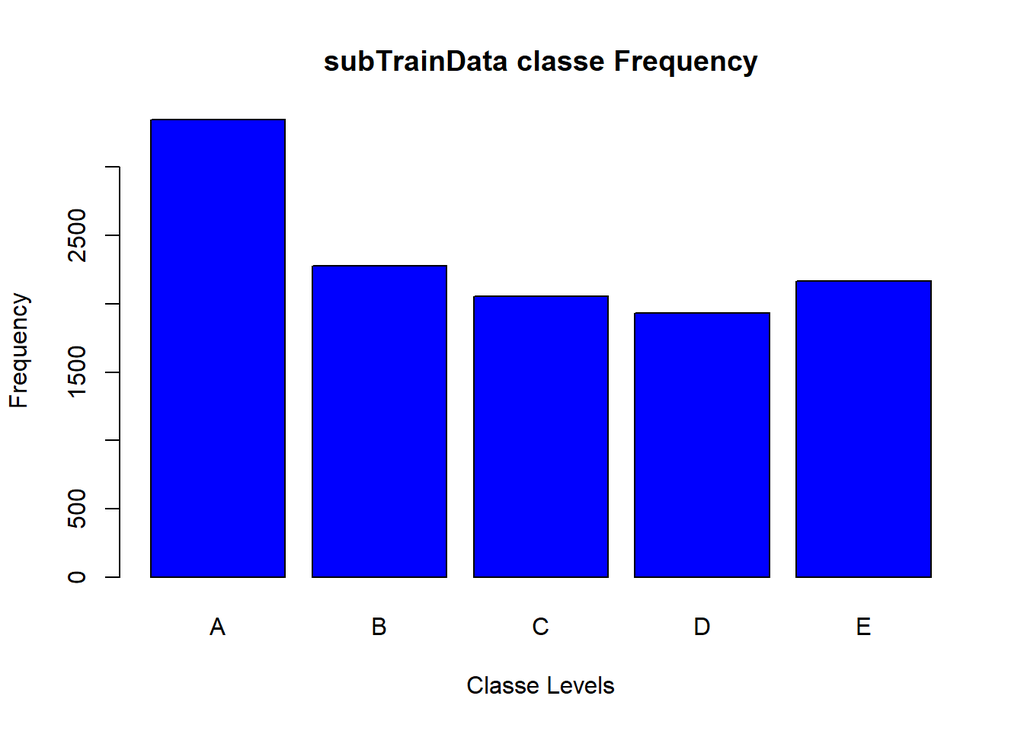

```r
library(ggplot2, quietly = TRUE)
plot(subTrainData$classe, col = "blue", main = "subTrainData classe Frequency", xlab = "Classe Levels", ylab = "Frequency")
```

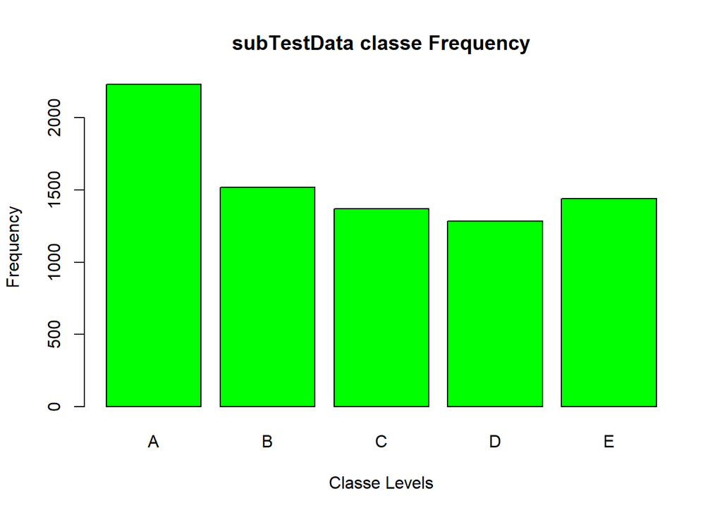

```r
plot(subTestData$classe, col = "green", main = "subTestData classe Frequency", xlab = "Classe Levels", ylab = "Frequency")
```

Both datasets appear to have good representation across the 5 classes, even if classe = A has a bit higher frequency. Now we’re ready to do some modeling!

## Models

Going to create three models and then assess which one should be used for the final predictive model.

```r
library(MASS, quietly = TRUE)
library(randomForest, quietly = TRUE)
library(gbm, quietly = TRUE)
library(plyr, quietly = TRUE)

# Have to add some items to get Random Forest to run quickly
rfControl <- trainControl(method = "none", number = 1, repeats = 1)

modLDA <- train(classe ~ ., data = subTrainData, method = "lda")
modGBM <- train(classe ~ ., data = subTrainData, method = "gbm", trControl = rfControl)
modRF <- train(classe ~ ., data = subTrainData, method = "rf", ntree=100, trControl = rfControl)

predLDA <- predict(modLDA, newdata = subTestData)
predGBM <- predict(modGBM, newdata = subTestData)
predRF <- predict(modRF, newdata = subTestData)
```

```r
confusionMatrix(predLDA, subTestData$classe)
```

```
## Confusion Matrix and Statistics
##
##           Reference
## Prediction    A    B    C    D    E
##          A 1870  256  143   72   61
##          B   35  956  155   52  250
##          C  162  187  866  161  131
##          D  159   63  162  949  129
##          E    6   56   42   52  871
##
## Overall Statistics
##
##                Accuracy : 0.7025
##                  95% CI : (0.6923, 0.7126)
##     No Information Rate : 0.2845
##     P-Value [Acc > NIR] : < 2.2e-16
##
##                   Kappa : 0.623
##  Mcnemar's Test P-Value : < 2.2e-16
##
## Statistics by Class:
##
##                      Class: A Class: B Class: C Class: D Class: E
## Sensitivity            0.8378   0.6298   0.6330   0.7379   0.6040
## Specificity            0.9052   0.9223   0.9010   0.9218   0.9756
## Pos Pred Value         0.7785   0.6602   0.5747   0.6491   0.8481
## Neg Pred Value         0.9335   0.9122   0.9208   0.9472   0.9163
## Prevalence             0.2845   0.1935   0.1744   0.1639   0.1838
## Detection Rate         0.2383   0.1218   0.1104   0.1210   0.1110
## Detection Prevalence   0.3061   0.1846   0.1921   0.1863   0.1309
## Balanced Accuracy      0.8715   0.7760   0.7670   0.8299   0.7898
```

### Cross Validate Gradient Boost Model (GBM)

```r
confusionMatrix(predGBM, subTestData$classe)
```

```
## Confusion Matrix and Statistics
##
##           Reference
## Prediction    A    B    C    D    E
##          A 1920  237  123  114   75
##          B   64  963  101   35  200
##          C   67  213 1071  144  115
##          D  168   99   70  912   72
##          E   13    6    3   81  980
##
## Overall Statistics
##
##                Accuracy : 0.7451
##                  95% CI : (0.7353, 0.7547)
##     No Information Rate : 0.2845
##     P-Value [Acc > NIR] : < 2.2e-16
##
##                   Kappa : 0.6766
##  Mcnemar's Test P-Value : < 2.2e-16
##
## Statistics by Class:
##
##                      Class: A Class: B Class: C Class: D Class: E
## Sensitivity            0.8602   0.6344   0.7829   0.7092   0.6796
## Specificity            0.9022   0.9368   0.9168   0.9377   0.9839
## Pos Pred Value         0.7776   0.7065   0.6652   0.6904   0.9049
## Neg Pred Value         0.9420   0.9144   0.9524   0.9427   0.9317
## Prevalence             0.2845   0.1935   0.1744   0.1639   0.1838
## Detection Rate         0.2447   0.1227   0.1365   0.1162   0.1249
## Detection Prevalence   0.3147   0.1737   0.2052   0.1684   0.1380
## Balanced Accuracy      0.8812   0.7856   0.8498   0.8234   0.8318
```

### Cross Validate Random Forest (RF) Model

```r
confusionMatrix(predRF, subTestData$classe)
```

```
## Confusion Matrix and Statistics
##
##           Reference
## Prediction    A    B    C    D    E
##          A 2228   16    0    0    0
##          B    2 1498   11    0    0
##          C    2    4 1353   17    5
##          D    0    0    4 1268    2
##          E    0    0    0    1 1435
##
## Overall Statistics
##
##                Accuracy : 0.9918
##                  95% CI : (0.9896, 0.9937)
##     No Information Rate : 0.2845
##     P-Value [Acc > NIR] : < 2.2e-16
##
##                   Kappa : 0.9897
##  Mcnemar's Test P-Value : NA
##
## Statistics by Class:
##
##                      Class: A Class: B Class: C Class: D Class: E
## Sensitivity            0.9982   0.9868   0.9890   0.9860   0.9951
## Specificity            0.9971   0.9979   0.9957   0.9991   0.9998
## Pos Pred Value         0.9929   0.9914   0.9797   0.9953   0.9993
## Neg Pred Value         0.9993   0.9968   0.9977   0.9973   0.9989
## Prevalence             0.2845   0.1935   0.1744   0.1639   0.1838
## Detection Rate         0.2840   0.1909   0.1724   0.1616   0.1829
## Detection Prevalence   0.2860   0.1926   0.1760   0.1624   0.1830
## Balanced Accuracy      0.9977   0.9924   0.9924   0.9925   0.9975
```

## Decision

I’m going to use the RandomForest model to test the last 20 items from the original test data we downloaded.

```r
final <- predict(modRF, testData)
final
```

```
##  [1] B A B A A E D B A A B C B A E E A B B B
## Levels: A B C D E
```